# Car Evaluation 🚗 2.0

## Lab Five: Evaluation and Multi-Layer Perceptron

### Justin Ledford, Luke Wood, Traian Pop

```python
%matplotlib inline
import numpy as np
import plotly
import pandas as pd
import matplotlib.pyplot as plt
import time

import warnings
warnings.filterwarnings('ignore')
```

## Business Understanding

### Background Knowledge

The classification task in this dataset is broken into 4 classes. This includes 'unacc' (unacceptable), 'acc' (acceptable), 'good' (good!), and 'v-good' (very good!). These conditions decrease in percentage in the dataset as you go down the list. There are a high value of "unacceptable" with almost 70% of the data belonging to this class, about 22% "acceptable", and about 4% each for "good" and "very good".

### Use-Case

One possible use for this dataset is to assist customers in purchasing the car quality that they desire and to assure customer satisfaction with their vehicle. Throughout this project, the way we measure 'success' is by minimizing 'unaccepted' false negatives. The reason we focus mainly on that metric, and less on the false negative of the other car qualities, is due to the significant damage a false negative in the 'unaccepted' car category can create.

Take for example someone comes in to a dealership with intent to buy an affordable family car. While the difference between purchasing an "acceptable" and "good" car might just be a slightly lower safety rank or a tad more expensive to maintain, a car that would be unacceptable could range anywhere extremely overpriced to a very low safety rating. Due to the range of "unacceptable" cars being fairly large (considering they are 70% of the dataset), the risk of someone being disappointed in an accidental false negative is quite high. While a dealership attempts to sell their worst possible car for the highest potential price to a consumer, they still have to meet the qualifications of the customer. If they oversell something or start lying, the repercussions for the dealership are huge and the risk is not worth it.

We are planning on getting a percentage value of over 90% but anything above that is really helpful. We think this appropriate due to the relative low cost activity needed in order to make someone go in person to look at the car instead of just relying on online descriptions. Although we will be able to eliminate the majority of the noise during a customer's search, they will still have to finalize specific details and the overall decision themselves.

## Data Preparation

The data originally consisted of categorical attributes with each value as a string:

buying: v-high, high, med, low  
maintain: v-high, high, med, low  
doors: 2, 3, 4, 5-more  
persons: 2, 4, more  
trunk: small, med, big  
safety: low, med, high

We converted the attributes to one hot encoding, and converted the class values to integers (0-3). Since the dataset only has a small amount of attributes, we decided to keep all of them, and that dimensionality reduction was not necessary with this data.

```python
#one-hot encoding method
df = pd.read_csv(
        'http://archive.ics.uci.edu/ml/machine-learning-databases/car/car.data',
        header=None)

df.columns = ['buying', 'maint', 'doors', 'persons', 'trunk', 'safety', 'class']

# One hot encode caegorical attributes
df_dummies = pd.get_dummies(df.drop('class', axis=1))

# Convert class to integers
y = df['class'].replace(to_replace=['unacc', 'acc', 'good', 'vgood'],
                        value=range(4)).values
X = df_dummies.values
```

```python
plotly.offline.init_notebook_mode() # run at the start of every notebook

graph1 = {'labels': ['Unacceptable', 'Acceptable', 'Good', 'Very good'],
          'values': np.bincount(y),
            'type': 'pie'}
fig = dict()
fig['data'] = [graph1]
fig['layout'] = {'title': 'Class Distribution',
                'autosize':False,
                'width':500,
                'height':300}

plotly.offline.iplot(fig)
```

[interactive chart not shown]

## Evaluation

### Metric Evaluation

With our data set and application, we believe it is most important to minimize the amount of false negatives for the "unacceptable class" because it would be unfortunate to classify a true unacceptable car as something acceptable, or even good/very good.

In order to do this we wrote a weighted recall score function that takes a cost matrix of the weights for each false negative. The recall score is still $tp / (tp + fn)$, but the values of $fn$ are now weighted according to the cost matrix.

We weighted any "unacceptable" false negative twice the cost as any other false negative.

```python
from sklearn.metrics import confusion_matrix

# High cost for false negatives on "unacceptable" class
weights = np.array([
    [0, 2, 2, 2],
    [1, 0, 1, 1],
    [1, 1, 0, 1],
    [1, 1, 1, 0]
])

def weighted_recall_score(y_true, y_pred, weight_matrix):
    conf_matrix = confusion_matrix(y_true, y_pred)

    tp = np.sum(np.diagonal(conf_matrix))
    fn = np.sum(weight_matrix * conf_matrix)

    return tp / (tp + fn)
```

### Dividing the Data

We chose stratified shuffle split as our cross validation method. Our data set is highly imbalanced (over 70% "unacceptable") so a stratified method is necessary. We chose shuffle split in order to use a higher training size with less iterations than k fold. Our method is similar to how it would be used in practice, our model will be used in production by giving it a sample of cars (new cars for the year/season, etc) and the class balance will likely be similar to how our training set is divided.

## Modeling the Perceptron

```python
from sklearn.model_selection import cross_val_score
from sklearn.model_selection import StratifiedKFold, StratifiedShuffleSplit

from sklearn.metrics import make_scorer, accuracy_score

import numpy as np
from scipy.special import expit
import pandas as pd
import sys
```

### Custom Perceptron

Here is our custom two layer perception. Currently you can either use the linear function for the first layer or your choice of the following nonlinear ones: sigmoid, Rectified Linear Units (relu), or tanh. In addition, you have to choose between the default quadratic cost function or use the Cross Entropy one.

```python
# just start with the vectorized version and minibatch
class MyTLP():
    def __init__(self, n_hidden=30,
                 l2_C=0.0, epochs=500, eta=0.001, random_state=None, alpha=0.0,
                 decrease_const=0.0, shuffle=True, minibatches=1, f_cost='quadratic',
                 f_layer="sigmoid", tanh_a=0.0, scorer=None):

        #original initializer
        np.random.seed(random_state)
        self.n_hidden = n_hidden
        self.l2_C = l2_C
        self.epochs = epochs
        self.eta = eta
        # need to add to the original initializer
        self.alpha = alpha
        self.decrease_const = decrease_const
        self.shuffle = shuffle
        self.minibatches = minibatches
        self.f_cost = f_cost
        self.f_layer = f_layer
        self.tanh_a = tanh_a

        if not scorer:
            self.scorer = make_scorer(accuracy_score)
        else:
            self.scorer = scorer

    def _initialize_weights(self):
        """Initialize weights with small random numbers."""
        if self.f_layer == 'relu':
            init_bound = np.sqrt(6. / (self.n_hidden + self.n_features_ + 1))
            W1 = np.random.uniform(-init_bound, init_bound,(self.n_hidden, self.n_features_ + 1))

            init_bound = np.sqrt(2. / (self.n_output_ + self.n_hidden + 1))
            W2 = np.random.uniform(-init_bound, init_bound,(self.n_output_, self.n_hidden + 1))

        #tanh & sigmoid has same initializations
        else:
            W1 = np.random.randn(self.n_hidden, self.n_features_ + 1)
            W1[:,1:] = W1[:,1:]/np.sqrt(self.n_features_+1) # don't saturate the neuron

            W2 = np.random.randn(self.n_output_, self.n_hidden + 1)
            W2[:,1:] = W2[:,1:]/np.sqrt(self.n_hidden+1) # don't saturate the neuron

        return W1, W2

    @staticmethod
    def _sigmoid(z):
        """Use scipy.special.expit to avoid overflow"""
        # 1.0 / (1.0 + np.exp(-z))
        return expit(z)

    @staticmethod
    def _relu(Z):
        return np.maximum(0,Z.copy())

    #@staticmethod
    def _tanh(self, Z):
        return np.tanh(Z) + (self.tanh_a * Z)

    def _feedforward(self, X, W1, W2):
        """Compute feedforward step
        """
        A1 = self._add_bias_unit(X, how='column')
        Z1 = W1 @ A1.T
        if self.f_layer == 'relu':
            A2 = self._relu(Z1)
        elif self.f_layer == 'tanh':
            A2 = self._tanh(Z1)
        #linear function
        elif self.f_layer == 'linear':
            A2 = Z1
        else:
            A2 = self._sigmoid(Z1)
        A2 = self._add_bias_unit(A2, how='row')
        Z2 = W2 @ A2
        A3 = self._sigmoid(Z2)
        return A1, Z1, A2, Z2, A3

    def fit(self, X, y, print_progress=False):
        """ Learn weights from training data. With mini-batch"""
        X_data, y_data = X.copy(), y.copy()
        Y_enc = self._encode_labels(y)

        # init weights and setup matrices
        self.n_features_ = X_data.shape[1]
        self.n_output_ = Y_enc.shape[0]
        self.W1, self.W2 = self._initialize_weights()

        delta_W1_prev = np.zeros(self.W1.shape)
        delta_W2_prev = np.zeros(self.W2.shape)

        self.cost_ = []
        self.score_ = []
        for i in range(self.epochs):

            # adaptive learning rate
            self.eta /= (1 + self.decrease_const*i)

            if print_progress>0 and (i+1)%print_progress==0:
                sys.stderr.write('\rEpoch: %d/%d' % (i+1, self.epochs))
                sys.stderr.flush()

            if self.shuffle:
                idx_shuffle = np.random.permutation(y_data.shape[0])
                X_data, Y_enc, y_data = X_data[idx_shuffle], Y_enc[:, idx_shuffle], y_data[idx_shuffle]

            mini = np.array_split(range(y_data.shape[0]), self.minibatches)
            mini_cost = []
            for idx in mini:

                # feedforward
                A1, Z1, A2, Z2, A3 = self._feedforward(X_data[idx],
                                                       self.W1,
                                                       self.W2)

                cost = self._cost(A3,Y_enc[:, idx],self.W1,self.W2)
                mini_cost.append(cost) # this appends cost of mini-batch only

                # compute gradient via backpropagation
                grad1, grad2 = self._get_gradient(A1=A1, A2=A2, A3=A3, Z1=Z1, Z2=Z2,
                                                  Y_enc=Y_enc[:, idx],
                                                  W1=self.W1,W2=self.W2)

                delta_W1, delta_W2 = self.eta * grad1, self.eta * grad2
                self.W1 -= (delta_W1 + (self.alpha * delta_W1_prev))
                self.W2 -= (delta_W2 + (self.alpha * delta_W2_prev))
                delta_W1_prev, delta_W2_prev = delta_W1, delta_W2

            self.cost_.append(mini_cost)
            self.score_.append(self.scorer(self, X_data, y_data))

    def get_params(self, deep=True):
        return {"alpha": self.alpha, "f_cost": self.f_cost, "f_layer": self.f_layer,
                "l2_C": self.l2_C,
               "eta": self.eta, "decrease_const": self.decrease_const, "epochs": self.epochs}

    def _cost(self,A3,Y_enc,W1,W2):
        # Cross entropy choice
        if self.f_cost == 'cross':
            '''Get the objective function value'''
            cost = np.mean((Y_enc-A3)**2)
            L2_term = self._L2_reg(self.l2_C, W1, W2)
            return cost + L2_term
        # Quadradic (default) choice
        else:
            '''Get the objective function value'''
            cost = -np.mean(np.nan_to_num((Y_enc*np.log(A3)+(1-Y_enc)*np.log(1-A3))))
            L2_term = self._L2_reg(self.l2_C, W1, W2)
            return cost + L2_term

    def _get_gradient(self, A1, A2, A3, Z1, Z2, Y_enc, W1, W2):
        # Cross entrophy choice
        if self.f_cost == 'cross':
            sigma3 = (A3-Y_enc)
        else:
            sigma3 = -2*(Y_enc-A3)*A3*(1-A3)

        # Relu choice
        if self.f_layer == 'relu' or self.f_layer == 'linear':
            sigma2 = (W2.T @ sigma3)
            Z1_with_bias = self._add_bias_unit(Z1,how='row')
            sigma2[Z1_with_bias<=0] = 0
        else:
            sigma2 = (W2.T @ sigma3)*A2*(1-A2)

        grad1 = sigma2[1:,:] @ A1
        grad2 = sigma3 @ A2.T

        # regularize weights that are not bias terms
        grad1[:, 1:] += W1[:, 1:] * self.l2_C
        grad2[:, 1:] += W2[:, 1:] * self.l2_C

        return grad1, grad2

    @staticmethod
    def _encode_labels(y):
        """Encode labels into one-hot representation"""
        onehot = pd.get_dummies(y).values.T

        return onehot

    @staticmethod
    def _add_bias_unit(X, how='column'):
        """Add bias unit (column or row of 1s) to array at index 0"""
        if how == 'column':
            ones = np.ones((X.shape[0], 1))
            X_new = np.hstack((ones, X))
        elif how == 'row':
            ones = np.ones((1, X.shape[1]))
            X_new = np.vstack((ones, X))
        return X_new

    @staticmethod
    def _L2_reg(lambda_, W1, W2):
        """Compute L2-regularization cost"""
        # only compute for non-bias terms
        return (lambda_/2.0) * np.sqrt(np.mean(W1[:, 1:] ** 2) + np.mean(W2[:, 1:] ** 2))

    def predict(self, X):
        """Predict class labels"""
        _, _, _, _, A3 = self._feedforward(X, self.W1, self.W2)
        y_pred = np.argmax(A3, axis=0)
        return y_pred

    def set_params(self, **parameters):
        for parameter, value in parameters.items():
            self.__setattr__(parameter, value)
        return self
```

In addition, we also created a custom scorer wrapper object in order to correctly calculate our desired metric.

```
(0.80521739130434777, 0.90804597701149425)
```

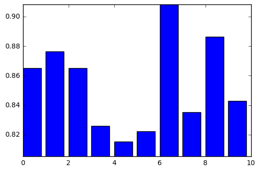

```python
from sklearn.pipeline import make_pipeline

def score_wrapper(score_f):
    def _score(y_true, y_pred, **kwargs):
        #print(confusion_matrix(y_true, y_pred))
        return score_f(y_true, y_pred, **kwargs)
    return _score


# select model
clf = MyTLP()
#select cross validation
cv = StratifiedShuffleSplit(n_splits=10, test_size=0.05)

#_score = score_wrapper(recall_score)
#my_scorer = make_scorer(_score, average='micro')
_score = score_wrapper(weighted_recall_score)
my_scorer = make_scorer(_score, weight_matrix=weights)

# run model training and cross validation
per_fold_eval_criteria = cross_val_score(estimator=clf,
                                    X=X,
                                    y=y,
                                    cv=cv,
                                    scoring=my_scorer
                                   )
plt.bar(range(len(per_fold_eval_criteria)),per_fold_eval_criteria)
plt.ylim([min(per_fold_eval_criteria)-0.01,max(per_fold_eval_criteria)])
```

After running our model a few times with different training sizes, we noticed a positive correlation between our weighted recall score and the size of the training set. We wanted to visualize the effect of the training set so we plotted a learning curve.

```python
# from ICA3 notebook (Eric Larson)
# https://github.com/eclarson/MachineLearningNotebooks
def plot_filled(test_scores,train_x_axis, xlabel=''):

    test_mean = np.percentile(test_scores,50, axis=1)
    test_max = np.percentile(test_scores,95, axis=1)
    test_min = np.percentile(test_scores,5, axis=1)

    plt.plot(train_x_axis, test_mean,
             color='blue', linestyle='--',
             marker='s', markersize=5,
             label='validation set')

    plt.fill_between(train_x_axis,
                     test_min,
                     test_max,
                     alpha=0.15, color='blue')

    plt.grid(True)
    plt.xlabel(xlabel)
    plt.ylabel('Evaluation Criterion')
    plt.legend(loc='lower right')
    plt.tight_layout()
```

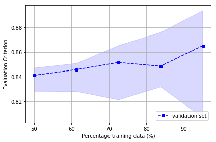

```python
#clf = MyTLP(f_layer='relu', f_cost='cross', alpha=0, decrease_const=1e-09,
#           epochs=500, l2_C=0.01)
clf = MyTLP()
my_scorer = make_scorer(weighted_recall_score, weight_matrix=weights)

test_scores = []
train_sizes=np.linspace(.5,.95,5)

for size in train_sizes:
    cv = StratifiedShuffleSplit(n_splits=10,
                                train_size = size,
                                test_size = 1-size,
                               )
    test_scores.append(cross_val_score(estimator=clf,X=X,y=y,cv=cv,scoring=my_scorer))

plot_filled(np.array(test_scores), train_sizes*100, 'Percentage training data (%)')
```

Next we wanted to see the learning rate for our different cost functions and first layer nonlinearity functions.

```python
# from Lecture 8 notebook (Eric Larson)
# https://github.com/eclarson/MachineLearningNotebooks
def print_result(nn,X_train,y_train,X_test,y_test,title="",color="red"):

    print("=================")
    print(title,":")
    yhat = nn.predict(X_train)
    print('Score',weighted_recall_score(y_train,yhat,weights))

    yhat = nn.predict(X_test)
    print('Score',weighted_recall_score(y_test,yhat,weights))

    plt.plot(range(len(nn.score_)), nn.score_, color=color,label=title)
    plt.ylabel('Score')

    plt.xlabel('Epochs')
    plt.tight_layout()
    plt.legend(loc='best')
    plt.grid(True)
```

```python
cv_test = StratifiedShuffleSplit(n_splits=1, test_size=0.05)

for train_indices, test_indices in cv_test.split(X, y):
    X_train, X_test = X[train_indices], X[test_indices]
    y_train, y_test = y[train_indices], y[test_indices]

my_scorer = make_scorer(weighted_recall_score, weight_matrix=weights)
```

```
Epoch: 500/500
```

```
=================
Cross Entropy :
Score 0.965621230398
Score 0.888888888889
=================
Quadratic :
Score 0.865201900238
Score 0.866666666667
```

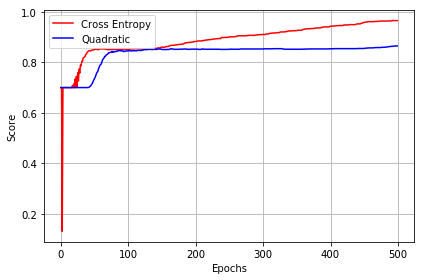

```python
tlp_quad = MyTLP(f_cost='quadratic', scorer=my_scorer)
tlp_cross = MyTLP(f_cost='cross', scorer=my_scorer)

tlp_cross.fit(X_train, y_train, print_progress=1)
tlp_quad.fit(X_train, y_train, print_progress=1)

print_result(tlp_cross,X_train,y_train,X_test,y_test,title="Cross Entropy",color="red")
print_result(tlp_quad,X_train,y_train,X_test,y_test,title="Quadratic",color="blue")
plt.show()
```

```
Epoch: 500/500
```

```
=================
sgmd :
Score 0.957280385078
Score 0.888888888889
=================
relu :
Score 0.998172959805
Score 0.954545454545
=================
linear :
Score 0.800703399766
Score 0.771739130435
=================
tanh :
Score 0.73637864612
Score 0.704081632653
```

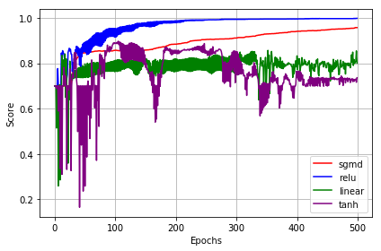

```python
tlp_sgmd = MyTLP(f_layer='sigmoid', f_cost='cross', scorer=my_scorer)
tlp_relu = MyTLP(f_layer='relu', f_cost='cross', scorer=my_scorer)
tlp_linear = MyTLP(f_layer='linear', f_cost='cross', scorer=my_scorer)
tlp_tanh = MyTLP(f_layer='tanh', tanh_a=0.0015, f_cost='cross', scorer=my_scorer)


tlp_sgmd.fit(X_train, y_train, print_progress=1)
tlp_relu.fit(X_train, y_train, print_progress=1)
tlp_linear.fit(X_train, y_train, print_progress=1)
tlp_tanh.fit(X_train, y_train, print_progress=1)


print_result(tlp_sgmd,X_train,y_train,X_test,y_test,title="sgmd",color="red")
print_result(tlp_relu,X_train,y_train,X_test,y_test,title="relu",color="blue")
print_result(tlp_linear,X_train,y_train,X_test,y_test,title="linear",color="green")
print_result(tlp_tanh,X_train,y_train,X_test,y_test,title="tanh",color="purple")

plt.show()
```

From the above plots we determined ReLU and cross entropy to be the best combination of functions in our model.

### Hyper-Parameter Tuning

#### GridSearchCV IRL (This might take a while)

First, we ran all of our hyper-parameter combinations through GridSearchCV in order to measure all of them against each other. Although this does not encompass EVERY possible parameter combination, the values we choose were based off of our material from the class.

```python
from sklearn.model_selection import GridSearchCV
from sklearn.pipeline import make_pipeline

# alpha, f_layer, f_cost, epochs, eta, C, decrease_const
parameters = {'f_cost':('cross',), 'f_layer':('relu','linear','sigmoid','tanh'), 'eta': [0.001, 0.01, 0.1],
              'epochs': [75], 'l2_C':[1e-2, 1e-1, 0.0],
              'decrease_const':[1e-9, 1e-5, 0.0], 'alpha':[0.0, 0.01, 0.001]}

tlp = MyTLP()

my_scorer = make_scorer(weighted_recall_score, weight_matrix=weights)
clf = GridSearchCV(tlp, parameters, scoring=my_scorer, cv=cv)
clf.fit(X, y)
results = pd.DataFrame(clf.cv_results_)
results.sort(columns=['mean_test_score'], ascending=False)
```

|  | mean_fit_time | mean_score_time | mean_test_score | mean_train_score | param_alpha | param_decrease_const | param_epochs | param_eta | param_f_cost | param_f_layer | ... | split7_test_score | split7_train_score | split8_test_score | split8_train_score | split9_test_score | split9_train_score | std_fit_time | std_score_time | std_test_score | std_train_score |
| --- | --- | --- | --- | --- | --- | --- | --- | --- | --- | --- | --- | --- | --- | --- | --- | --- | --- | --- | --- | --- | --- |
| 36 | 0.340977 | 0.000610 | 0.928958 | 0.938053 | 0 | 1e-05 | 75 | 0.001 | cross | relu | ... | 0.909091 | 0.939854 | 0.908046 | 0.931956 | 0.931034 | 0.938825 | 0.005938 | 0.000201 | 0.022616 | 0.005940 |
| 73 | 0.339560 | 0.000536 | 0.925800 | 0.931939 | 0 | 0 | 75 | 0.001 | cross | relu | ... | 0.896552 | 0.940389 | 0.877778 | 0.878006 | 0.919540 | 0.932646 | 0.005728 | 0.000005 | 0.032762 | 0.018979 |
| 253 | 0.340508 | 0.000542 | 0.925066 | 0.935181 | 0.001 | 1e-05 | 75 | 0.001 | cross | relu | ... | 0.886364 | 0.941105 | 0.877778 | 0.865463 | 0.896552 | 0.924757 | 0.005664 | 0.000012 | 0.039895 | 0.025397 |
| 181 | 0.343761 | 0.000548 | 0.923685 | 0.935508 | 0.01 | 0 | 75 | 0.001 | cross | relu | ... | 0.909091 | 0.946505 | 0.931034 | 0.951427 | 0.919540 | 0.940606 | 0.005319 | 0.000014 | 0.022731 | 0.018695 |
| 38 | 0.347026 | 0.000559 | 0.921685 | 0.923553 | 0 | 1e-05 | 75 | 0.001 | cross | relu | ... | 0.919540 | 0.927096 | 0.931034 | 0.928053 | 0.919540 | 0.945355 | 0.006689 | 0.000028 | 0.033658 | 0.027172 |
| 218 | 0.341508 | 0.000538 | 0.920271 | 0.935506 | 0.001 | 1e-09 | 75 | 0.001 | cross | relu | ... | 0.909091 | 0.942284 | 0.942529 | 0.953248 | 0.954023 | 0.933252 | 0.006400 | 0.000012 | 0.043352 | 0.023159 |
| 145 | 0.345861 | 0.000553 | 0.919401 | 0.933306 | 0.01 | 1e-05 | 75 | 0.001 | cross | relu | ... | 0.897727 | 0.944848 | 0.910112 | 0.891955 | 0.942529 | 0.945930 | 0.006264 | 0.000019 | 0.027193 | 0.021437 |
| 180 | 0.343913 | 0.000553 | 0.917807 | 0.932595 | 0.01 | 0 | 75 | 0.001 | cross | relu | ... | 0.909091 | 0.956944 | 0.919540 | 0.944748 | 0.887640 | 0.892353 | 0.003792 | 0.000021 | 0.039580 | 0.020288 |
| 2 | 0.358651 | 0.000584 | 0.915075 | 0.927301 | 0 | 1e-09 | 75 | 0.001 | cross | relu | ... | 0.886364 | 0.941212 | 0.942529 | 0.953855 | 0.876404 | 0.882319 | 0.019686 | 0.000023 | 0.037491 | 0.026756 |
| 290 | 0.338045 | 0.000534 | 0.912907 | 0.923026 | 0.001 | 0 | 75 | 0.001 | cross | relu | ... | 0.886364 | 0.936817 | 0.931034 | 0.935680 | 0.897727 | 0.908660 | 0.005754 | 0.000004 | 0.039504 | 0.022617 |
| 216 | 0.347687 | 0.000544 | 0.909370 | 0.930620 | 0.001 | 1e-09 | 75 | 0.001 | cross | relu | ... | 0.863636 | 0.935641 | 0.919540 | 0.944141 | 0.855556 | 0.888889 | 0.008326 | 0.000014 | 0.039764 | 0.023837 |
| 288 | 0.340555 | 0.000569 | 0.907393 | 0.932692 | 0.001 | 0 | 75 | 0.001 | cross | relu | ... | 0.863636 | 0.938144 | 0.931034 | 0.953827 | 0.931034 | 0.945455 | 0.004770 | 0.000088 | 0.051317 | 0.034116 |
| 254 | 0.338842 | 0.000537 | 0.905455 | 0.918565 | 0.001 | 1e-05 | 75 | 0.001 | cross | relu | ... | 0.836957 | 0.876313 | 0.942529 | 0.944175 | 0.919540 | 0.946699 | 0.005838 | 0.000006 | 0.042141 | 0.031281 |
| 0 | 0.350217 | 0.000586 | 0.903733 | 0.922665 | 0 | 1e-09 | 75 | 0.001 | cross | relu | ... | 0.866667 | 0.908121 | 0.942529 | 0.929569 | 0.931034 | 0.944748 | 0.011088 | 0.000015 | 0.044421 | 0.028028 |
| 72 | 0.342375 | 0.000538 | 0.903620 | 0.922571 | 0 | 0 | 75 | 0.001 | cross | relu | ... | 0.942529 | 0.949697 | 0.847826 | 0.883626 | 0.931034 | 0.937538 | 0.003784 | 0.000010 | 0.042937 | 0.027047 |
| 182 | 0.345962 | 0.000551 | 0.902334 | 0.926633 | 0.01 | 0 | 75 | 0.001 | cross | relu | ... | 0.875000 | 0.940000 | 0.919540 | 0.924939 | 0.931034 | 0.948328 | 0.008669 | 0.000021 | 0.039232 | 0.024925 |
| 252 | 0.341225 | 0.000553 | 0.901697 | 0.921071 | 0.001 | 1e-05 | 75 | 0.001 | cross | relu | ... | 0.886364 | 0.926667 | 0.931034 | 0.944782 | 0.908046 | 0.942996 | 0.004882 | 0.000023 | 0.046705 | 0.031293 |
| 217 | 0.339835 | 0.000535 | 0.901584 | 0.918371 | 0.001 | 1e-09 | 75 | 0.001 | cross | relu | ... | 0.908046 | 0.947112 | 0.920455 | 0.910279 | 0.919540 | 0.943534 | 0.006847 | 0.000011 | 0.037138 | 0.027316 |
| 110 | 0.347659 | 0.000550 | 0.901382 | 0.924495 | 0.01 | 1e-09 | 75 | 0.001 | cross | relu | ... | 0.875000 | 0.940534 | 0.846154 | 0.858960 | 0.919540 | 0.941818 | 0.005861 | 0.000016 | 0.038383 | 0.035488 |
| 289 | 0.337160 | 0.000539 | 0.900962 | 0.904300 | 0.001 | 0 | 75 | 0.001 | cross | relu | ... | 0.908046 | 0.927747 | 0.919540 | 0.925881 | 0.855556 | 0.852345 | 0.004548 | 0.000009 | 0.040287 | 0.035264 |
| 144 | 0.340498 | 0.000539 | 0.899466 | 0.912149 | 0.01 | 1e-05 | 75 | 0.001 | cross | relu | ... | 0.909091 | 0.947816 | 0.857143 | 0.856730 | 0.931034 | 0.950939 | 0.006203 | 0.000012 | 0.036462 | 0.031072 |
| 1 | 0.343617 | 0.000584 | 0.896804 | 0.913403 | 0 | 1e-09 | 75 | 0.001 | cross | relu | ... | 0.886364 | 0.936402 | 0.919540 | 0.947177 | 0.919540 | 0.937084 | 0.006728 | 0.000052 | 0.029658 | 0.035286 |
| 146 | 0.340845 | 0.000541 | 0.894611 | 0.910546 | 0.01 | 1e-05 | 75 | 0.001 | cross | relu | ... | 0.847826 | 0.877480 | 0.877778 | 0.880632 | 0.908046 | 0.941748 | 0.006534 | 0.000011 | 0.047771 | 0.030147 |
| 108 | 0.347397 | 0.000558 | 0.893860 | 0.911049 | 0.01 | 1e-09 | 75 | 0.001 | cross | relu | ... | 0.875000 | 0.944175 | 0.857143 | 0.841924 | 0.919540 | 0.944209 | 0.007773 | 0.000021 | 0.038560 | 0.040090 |
| 109 | 0.344559 | 0.000556 | 0.891815 | 0.915743 | 0.01 | 1e-09 | 75 | 0.001 | cross | relu | ... | 0.847826 | 0.887845 | 0.887640 | 0.882904 | 0.866667 | 0.889019 | 0.006519 | 0.000020 | 0.035619 | 0.031731 |
| 74 | 0.340999 | 0.000598 | 0.891197 | 0.907049 | 0 | 0 | 75 | 0.001 | cross | relu | ... | 0.836957 | 0.873396 | 0.908046 | 0.938602 | 0.919540 | 0.951309 | 0.005034 | 0.000187 | 0.045307 | 0.036762 |
| 37 | 0.340954 | 0.000537 | 0.889392 | 0.907873 | 0 | 1e-05 | 75 | 0.001 | cross | relu | ... | 0.886364 | 0.941176 | 0.919540 | 0.947145 | 0.835165 | 0.821388 | 0.004458 | 0.000010 | 0.046289 | 0.039484 |
| 45 | 0.464995 | 0.000600 | 0.859380 | 0.878696 | 0 | 1e-05 | 75 | 0.001 | cross | tanh | ... | 0.887640 | 0.887900 | 0.876404 | 0.893516 | 0.886364 | 0.887164 | 0.018025 | 0.000022 | 0.047102 | 0.022395 |
| 82 | 0.462439 | 0.000656 | 0.855549 | 0.866608 | 0 | 0 | 75 | 0.001 | cross | tanh | ... | 0.776596 | 0.753059 | 0.898876 | 0.905582 | 0.875000 | 0.889684 | 0.023774 | 0.000177 | 0.048924 | 0.041860 |
| 189 | 0.459397 | 0.000584 | 0.855548 | 0.856543 | 0.01 | 0 | 75 | 0.001 | cross | tanh | ... | 0.876404 | 0.895995 | 0.865169 | 0.896367 | 0.897727 | 0.889087 | 0.018624 | 0.000008 | 0.059374 | 0.058986 |
| ... | ... | ... | ... | ... | ... | ... | ... | ... | ... | ... | ... | ... | ... | ... | ... | ... | ... | ... | ... | ... | ... |
| 177 | 0.353334 | 0.000545 | 0.440960 | 0.440074 | 0.01 | 1e-05 | 75 | 0.1 | cross | tanh | ... | 0.701149 | 0.700183 | 0.020270 | 0.022222 | 0.701149 | 0.700183 | 0.012149 | 0.000014 | 0.319931 | 0.319934 |
| 23 | 0.374512 | 0.000565 | 0.428798 | 0.429035 | 0 | 1e-09 | 75 | 0.01 | cross | tanh | ... | 0.701149 | 0.700183 | 0.020270 | 0.022222 | 0.701149 | 0.700183 | 0.007742 | 0.000016 | 0.333561 | 0.332087 |
| 140 | 0.444913 | 0.000577 | 0.427582 | 0.431708 | 0.01 | 1e-09 | 75 | 0.1 | cross | sigmoid | ... | 0.701149 | 0.700183 | 0.027027 | 0.023297 | 0.701149 | 0.700183 | 0.008433 | 0.000014 | 0.296828 | 0.296969 |
| 96 | 0.303019 | 0.000527 | 0.414764 | 0.415504 | 0 | 0 | 75 | 0.1 | cross | relu | ... | 0.701149 | 0.700183 | 0.128378 | 0.130824 | 0.701149 | 0.700183 | 0.003349 | 0.000012 | 0.286386 | 0.284679 |
| 97 | 0.304131 | 0.000531 | 0.414764 | 0.415504 | 0 | 0 | 75 | 0.1 | cross | relu | ... | 0.128378 | 0.130824 | 0.128378 | 0.130824 | 0.701149 | 0.700183 | 0.005045 | 0.000024 | 0.286386 | 0.284679 |
| 25 | 0.306718 | 0.000532 | 0.414764 | 0.415504 | 0 | 1e-09 | 75 | 0.1 | cross | relu | ... | 0.128378 | 0.130824 | 0.701149 | 0.700183 | 0.128378 | 0.130824 | 0.003911 | 0.000017 | 0.286386 | 0.284679 |
| 278 | 0.300030 | 0.000530 | 0.414764 | 0.415504 | 0.001 | 1e-05 | 75 | 0.1 | cross | relu | ... | 0.701149 | 0.700183 | 0.701149 | 0.700183 | 0.701149 | 0.700183 | 0.003309 | 0.000013 | 0.286386 | 0.284679 |
| 132 | 0.309666 | 0.000537 | 0.404629 | 0.404751 | 0.01 | 1e-09 | 75 | 0.1 | cross | relu | ... | 0.701149 | 0.700183 | 0.027027 | 0.023297 | 0.701149 | 0.700183 | 0.007973 | 0.000014 | 0.297903 | 0.296993 |
| 62 | 0.301802 | 0.000522 | 0.404629 | 0.404751 | 0 | 1e-05 | 75 | 0.1 | cross | relu | ... | 0.128378 | 0.130824 | 0.027027 | 0.023297 | 0.701149 | 0.700183 | 0.005578 | 0.000012 | 0.297903 | 0.296993 |
| 61 | 0.302802 | 0.000527 | 0.404629 | 0.404751 | 0 | 1e-05 | 75 | 0.1 | cross | relu | ... | 0.128378 | 0.130824 | 0.701149 | 0.700183 | 0.701149 | 0.700183 | 0.006164 | 0.000015 | 0.297903 | 0.296993 |
| 60 | 0.303155 | 0.000527 | 0.404629 | 0.404751 | 0 | 1e-05 | 75 | 0.1 | cross | relu | ... | 0.128378 | 0.130824 | 0.701149 | 0.700183 | 0.701149 | 0.700183 | 0.005191 | 0.000011 | 0.297903 | 0.296993 |
| 169 | 0.300109 | 0.000527 | 0.403953 | 0.404643 | 0.01 | 1e-05 | 75 | 0.1 | cross | relu | ... | 0.701149 | 0.700183 | 0.701149 | 0.700183 | 0.701149 | 0.700183 | 0.002955 | 0.000031 | 0.298765 | 0.297131 |
| 205 | 0.301865 | 0.000523 | 0.403953 | 0.404643 | 0.01 | 0 | 75 | 0.1 | cross | relu | ... | 0.701149 | 0.700183 | 0.128378 | 0.130824 | 0.701149 | 0.700183 | 0.003984 | 0.000013 | 0.298765 | 0.297131 |
| 129 | 0.377392 | 0.000568 | 0.394494 | 0.393962 | 0.01 | 1e-09 | 75 | 0.01 | cross | tanh | ... | 0.128378 | 0.130824 | 0.701149 | 0.700183 | 0.701149 | 0.700183 | 0.014266 | 0.000017 | 0.308659 | 0.308473 |
| 66 | 0.447815 | 0.000569 | 0.393818 | 0.393891 | 0 | 1e-05 | 75 | 0.1 | cross | sigmoid | ... | 0.701149 | 0.700183 | 0.701149 | 0.700183 | 0.020270 | 0.022222 | 0.005950 | 0.000006 | 0.309469 | 0.308571 |
| 30 | 0.448463 | 0.000572 | 0.393818 | 0.393891 | 0 | 1e-09 | 75 | 0.1 | cross | sigmoid | ... | 0.701149 | 0.700183 | 0.128378 | 0.130824 | 0.027027 | 0.023297 | 0.009635 | 0.000014 | 0.309469 | 0.308571 |
| 276 | 0.299877 | 0.000527 | 0.383683 | 0.383138 | 0.001 | 1e-05 | 75 | 0.1 | cross | relu | ... | 0.027027 | 0.023297 | 0.027027 | 0.023297 | 0.701149 | 0.700183 | 0.004773 | 0.000012 | 0.319494 | 0.319240 |
| 282 | 0.443919 | 0.000571 | 0.383007 | 0.383030 | 0.001 | 1e-05 | 75 | 0.1 | cross | sigmoid | ... | 0.701149 | 0.700183 | 0.701149 | 0.700183 | 0.701149 | 0.700183 | 0.007019 | 0.000013 | 0.320253 | 0.319361 |
| 277 | 0.298678 | 0.000549 | 0.357487 | 0.358568 | 0.001 | 1e-05 | 75 | 0.1 | cross | relu | ... | 0.128378 | 0.130824 | 0.701149 | 0.700183 | 0.128378 | 0.130824 | 0.001519 | 0.000073 | 0.280599 | 0.278928 |
| 240 | 0.303114 | 0.000530 | 0.357487 | 0.358568 | 0.001 | 1e-09 | 75 | 0.1 | cross | relu | ... | 0.128378 | 0.130824 | 0.128378 | 0.130824 | 0.128378 | 0.130824 | 0.007429 | 0.000021 | 0.280599 | 0.278928 |
| 168 | 0.300078 | 0.000524 | 0.336541 | 0.336955 | 0.01 | 1e-05 | 75 | 0.1 | cross | relu | ... | 0.128378 | 0.130824 | 0.701149 | 0.700183 | 0.128378 | 0.130824 | 0.004774 | 0.000012 | 0.300152 | 0.299188 |
| 133 | 0.308326 | 0.000543 | 0.336541 | 0.336955 | 0.01 | 1e-09 | 75 | 0.1 | cross | relu | ... | 0.027027 | 0.023297 | 0.128378 | 0.130824 | 0.128378 | 0.130824 | 0.009703 | 0.000021 | 0.300152 | 0.299188 |
| 318 | 0.446735 | 0.000571 | 0.325730 | 0.326095 | 0.001 | 0 | 75 | 0.1 | cross | sigmoid | ... | 0.701149 | 0.700183 | 0.128378 | 0.130824 | 0.701149 | 0.700183 | 0.007453 | 0.000012 | 0.309263 | 0.308305 |
| 24 | 0.304738 | 0.000532 | 0.290075 | 0.290879 | 0 | 1e-09 | 75 | 0.1 | cross | relu | ... | 0.128378 | 0.130824 | 0.701149 | 0.700183 | 0.128378 | 0.130824 | 0.005174 | 0.000014 | 0.270743 | 0.269795 |
| 206 | 0.301340 | 0.000524 | 0.278588 | 0.279911 | 0.01 | 0 | 75 | 0.1 | cross | relu | ... | 0.128378 | 0.130824 | 0.701149 | 0.700183 | 0.020270 | 0.022222 | 0.004569 | 0.000011 | 0.279633 | 0.278177 |
| 59 | 0.370106 | 0.000555 | 0.268453 | 0.269159 | 0 | 1e-05 | 75 | 0.01 | cross | tanh | ... | 0.701149 | 0.700183 | 0.128378 | 0.130824 | 0.027027 | 0.023297 | 0.008557 | 0.000013 | 0.286642 | 0.285709 |
| 98 | 0.306748 | 0.000533 | 0.232797 | 0.233943 | 0 | 0 | 75 | 0.1 | cross | relu | ... | 0.128378 | 0.130824 | 0.128378 | 0.130824 | 0.701149 | 0.700183 | 0.005382 | 0.000015 | 0.236087 | 0.235280 |
| 134 | 0.305335 | 0.000525 | 0.232122 | 0.233836 | 0.01 | 1e-09 | 75 | 0.1 | cross | relu | ... | 0.128378 | 0.130824 | 0.701149 | 0.700183 | 0.020270 | 0.022222 | 0.008615 | 0.000016 | 0.236684 | 0.235376 |
| 241 | 0.304332 | 0.000545 | 0.222662 | 0.223191 | 0.001 | 1e-09 | 75 | 0.1 | cross | relu | ... | 0.701149 | 0.700183 | 0.128378 | 0.130824 | 0.128378 | 0.130824 | 0.005910 | 0.000045 | 0.242442 | 0.242105 |
| 26 | 0.304798 | 0.000525 | 0.221987 | 0.223083 | 0 | 1e-09 | 75 | 0.1 | cross | relu | ... | 0.128378 | 0.130824 | 0.128378 | 0.130824 | 0.020270 | 0.022222 | 0.003686 | 0.000013 | 0.242995 | 0.242194 |

324 rows × 37 columns

Afterwards, we simply filtered out the columns we were most interested in, which are all the hyper-parameters combinations and their respective results.

```python
filtered_results = results[['mean_test_score','mean_train_score', 'param_alpha',
                            'param_decrease_const', 'param_epochs', 'param_eta', 'param_f_cost',
                           'param_f_layer', 'param_l2_C']]
filtered_results.sort(columns=['mean_test_score'], ascending=False)
```

|  | mean_test_score | mean_train_score | param_alpha | param_decrease_const | param_epochs | param_eta | param_f_cost | param_f_layer | param_l2_C |
| --- | --- | --- | --- | --- | --- | --- | --- | --- | --- |
| 36 | 0.928958 | 0.938053 | 0 | 1e-05 | 75 | 0.001 | cross | relu | 0.01 |
| 73 | 0.925800 | 0.931939 | 0 | 0 | 75 | 0.001 | cross | relu | 0.1 |
| 253 | 0.925066 | 0.935181 | 0.001 | 1e-05 | 75 | 0.001 | cross | relu | 0.1 |
| 181 | 0.923685 | 0.935508 | 0.01 | 0 | 75 | 0.001 | cross | relu | 0.1 |
| 38 | 0.921685 | 0.923553 | 0 | 1e-05 | 75 | 0.001 | cross | relu | 0 |
| 218 | 0.920271 | 0.935506 | 0.001 | 1e-09 | 75 | 0.001 | cross | relu | 0 |
| 145 | 0.919401 | 0.933306 | 0.01 | 1e-05 | 75 | 0.001 | cross | relu | 0.1 |
| 180 | 0.917807 | 0.932595 | 0.01 | 0 | 75 | 0.001 | cross | relu | 0.01 |
| 2 | 0.915075 | 0.927301 | 0 | 1e-09 | 75 | 0.001 | cross | relu | 0 |
| 290 | 0.912907 | 0.923026 | 0.001 | 0 | 75 | 0.001 | cross | relu | 0 |
| 216 | 0.909370 | 0.930620 | 0.001 | 1e-09 | 75 | 0.001 | cross | relu | 0.01 |
| 288 | 0.907393 | 0.932692 | 0.001 | 0 | 75 | 0.001 | cross | relu | 0.01 |
| 254 | 0.905455 | 0.918565 | 0.001 | 1e-05 | 75 | 0.001 | cross | relu | 0 |
| 0 | 0.903733 | 0.922665 | 0 | 1e-09 | 75 | 0.001 | cross | relu | 0.01 |
| 72 | 0.903620 | 0.922571 | 0 | 0 | 75 | 0.001 | cross | relu | 0.01 |
| 182 | 0.902334 | 0.926633 | 0.01 | 0 | 75 | 0.001 | cross | relu | 0 |
| 252 | 0.901697 | 0.921071 | 0.001 | 1e-05 | 75 | 0.001 | cross | relu | 0.01 |
| 217 | 0.901584 | 0.918371 | 0.001 | 1e-09 | 75 | 0.001 | cross | relu | 0.1 |
| 110 | 0.901382 | 0.924495 | 0.01 | 1e-09 | 75 | 0.001 | cross | relu | 0 |
| 289 | 0.900962 | 0.904300 | 0.001 | 0 | 75 | 0.001 | cross | relu | 0.1 |
| 144 | 0.899466 | 0.912149 | 0.01 | 1e-05 | 75 | 0.001 | cross | relu | 0.01 |
| 1 | 0.896804 | 0.913403 | 0 | 1e-09 | 75 | 0.001 | cross | relu | 0.1 |
| 146 | 0.894611 | 0.910546 | 0.01 | 1e-05 | 75 | 0.001 | cross | relu | 0 |
| 108 | 0.893860 | 0.911049 | 0.01 | 1e-09 | 75 | 0.001 | cross | relu | 0.01 |
| 109 | 0.891815 | 0.915743 | 0.01 | 1e-09 | 75 | 0.001 | cross | relu | 0.1 |
| 74 | 0.891197 | 0.907049 | 0 | 0 | 75 | 0.001 | cross | relu | 0 |
| 37 | 0.889392 | 0.907873 | 0 | 1e-05 | 75 | 0.001 | cross | relu | 0.1 |
| 45 | 0.859380 | 0.878696 | 0 | 1e-05 | 75 | 0.001 | cross | tanh | 0.01 |
| 82 | 0.855549 | 0.866608 | 0 | 0 | 75 | 0.001 | cross | tanh | 0.1 |
| 189 | 0.855548 | 0.856543 | 0.01 | 0 | 75 | 0.001 | cross | tanh | 0.01 |
| ... | ... | ... | ... | ... | ... | ... | ... | ... | ... |
| 177 | 0.440960 | 0.440074 | 0.01 | 1e-05 | 75 | 0.1 | cross | tanh | 0.01 |
| 23 | 0.428798 | 0.429035 | 0 | 1e-09 | 75 | 0.01 | cross | tanh | 0 |
| 140 | 0.427582 | 0.431708 | 0.01 | 1e-09 | 75 | 0.1 | cross | sigmoid | 0 |
| 96 | 0.414764 | 0.415504 | 0 | 0 | 75 | 0.1 | cross | relu | 0.01 |
| 97 | 0.414764 | 0.415504 | 0 | 0 | 75 | 0.1 | cross | relu | 0.1 |
| 25 | 0.414764 | 0.415504 | 0 | 1e-09 | 75 | 0.1 | cross | relu | 0.1 |
| 278 | 0.414764 | 0.415504 | 0.001 | 1e-05 | 75 | 0.1 | cross | relu | 0 |
| 132 | 0.404629 | 0.404751 | 0.01 | 1e-09 | 75 | 0.1 | cross | relu | 0.01 |
| 62 | 0.404629 | 0.404751 | 0 | 1e-05 | 75 | 0.1 | cross | relu | 0 |
| 61 | 0.404629 | 0.404751 | 0 | 1e-05 | 75 | 0.1 | cross | relu | 0.1 |
| 60 | 0.404629 | 0.404751 | 0 | 1e-05 | 75 | 0.1 | cross | relu | 0.01 |
| 169 | 0.403953 | 0.404643 | 0.01 | 1e-05 | 75 | 0.1 | cross | relu | 0.1 |
| 205 | 0.403953 | 0.404643 | 0.01 | 0 | 75 | 0.1 | cross | relu | 0.1 |
| 129 | 0.394494 | 0.393962 | 0.01 | 1e-09 | 75 | 0.01 | cross | tanh | 0.01 |
| 66 | 0.393818 | 0.393891 | 0 | 1e-05 | 75 | 0.1 | cross | sigmoid | 0.01 |
| 30 | 0.393818 | 0.393891 | 0 | 1e-09 | 75 | 0.1 | cross | sigmoid | 0.01 |
| 276 | 0.383683 | 0.383138 | 0.001 | 1e-05 | 75 | 0.1 | cross | relu | 0.01 |
| 282 | 0.383007 | 0.383030 | 0.001 | 1e-05 | 75 | 0.1 | cross | sigmoid | 0.01 |
| 277 | 0.357487 | 0.358568 | 0.001 | 1e-05 | 75 | 0.1 | cross | relu | 0.1 |
| 240 | 0.357487 | 0.358568 | 0.001 | 1e-09 | 75 | 0.1 | cross | relu | 0.01 |
| 168 | 0.336541 | 0.336955 | 0.01 | 1e-05 | 75 | 0.1 | cross | relu | 0.01 |
| 133 | 0.336541 | 0.336955 | 0.01 | 1e-09 | 75 | 0.1 | cross | relu | 0.1 |
| 318 | 0.325730 | 0.326095 | 0.001 | 0 | 75 | 0.1 | cross | sigmoid | 0.01 |
| 24 | 0.290075 | 0.290879 | 0 | 1e-09 | 75 | 0.1 | cross | relu | 0.01 |
| 206 | 0.278588 | 0.279911 | 0.01 | 0 | 75 | 0.1 | cross | relu | 0 |
| 59 | 0.268453 | 0.269159 | 0 | 1e-05 | 75 | 0.01 | cross | tanh | 0 |
| 98 | 0.232797 | 0.233943 | 0 | 0 | 75 | 0.1 | cross | relu | 0 |
| 134 | 0.232122 | 0.233836 | 0.01 | 1e-09 | 75 | 0.1 | cross | relu | 0 |
| 241 | 0.222662 | 0.223191 | 0.001 | 1e-09 | 75 | 0.1 | cross | relu | 0.1 |
| 26 | 0.221987 | 0.223083 | 0 | 1e-09 | 75 | 0.1 | cross | relu | 0 |

324 rows × 9 columns

Lastly, we will graph all the numeric hyper-parameters in order to better see which values are most optimal for our specific problem.

```python
# http://scikit-learn.org/stable/auto_examples/model_selection/plot_validation_curve.html
from sklearn.model_selection import validation_curve

def plot_validation_curve(train_scores, test_scores, param_label):
    train_scores_mean = np.mean(train_scores, axis=1)
    train_scores_std = np.std(train_scores, axis=1)
    test_scores_mean = np.mean(test_scores, axis=1)
    test_scores_std = np.std(test_scores, axis=1)

    plt.title("Validation Curve with TLP")
    plt.xlabel(param_label)
    plt.ylabel("Score")
    plt.ylim(0.0, 1.1)
    lw = 2
    plt.semilogx(param_range, train_scores_mean, label="Training score",
                 color="darkorange", lw=lw)
    plt.fill_between(param_range, train_scores_mean - train_scores_std,
                     train_scores_mean + train_scores_std, alpha=0.2,
                     color="darkorange", lw=lw)
    plt.semilogx(param_range, test_scores_mean, label="Cross-validation score",
                 color="navy", lw=lw)
    plt.fill_between(param_range, test_scores_mean - test_scores_std,
                     test_scores_mean + test_scores_std, alpha=0.2,
                     color="navy", lw=lw)
    plt.legend(loc="best")
```

```python
# validate eta
clf = MyTLP(f_layer='relu', f_cost='cross', alpha=0, decrease_const=1e-09,
           epochs=150)

param_range = np.logspace(-3.5, -2.5, 5)
train_scores, test_scores = validation_curve(clf, X, y, 'eta',
                                             param_range=param_range,
                                             cv=cv,
                                             scoring=my_scorer,
                                             n_jobs=4)
```

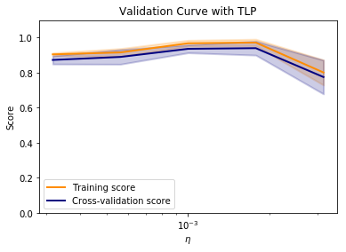

```python
plot_validation_curve(train_scores, test_scores, "$\eta$")
```

Our model has the highest score when $\eta$ is about $10^{-2.75}$.

```python
# validate decrease_const
clf = MyTLP(f_layer='relu', f_cost='cross', alpha=0, eta=10**-2.75,
           epochs=150)

param_range = np.logspace(-9, -1, 5)
train_scores, test_scores = validation_curve(clf, X, y, 'decrease_const',
                                             param_range=param_range,
                                             cv=cv,
                                             scoring=my_scorer,
                                             n_jobs=4)
```

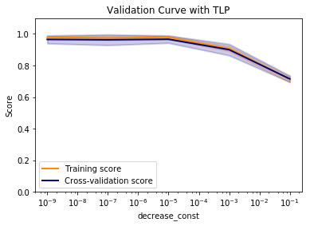

```python
plot_validation_curve(train_scores, test_scores, "decrease_const")
```

The score is about constant when the decreasing constant is from $10^{-9}$ to $10^{-5}$, but anything greater and the score starts to decrease, so we keep it $10^{-7}$.

```python
# validate alpha
clf = MyTLP(f_layer='relu', f_cost='cross', eta=10**-2.75,
            decrease_const=1e-7, epochs=150)

param_range = np.logspace(-9, -1, 5)
train_scores, test_scores = validation_curve(clf, X, y, 'alpha',
                                             param_range=param_range,
                                             cv=cv,
                                             scoring=my_scorer,
                                             n_jobs=4)
```

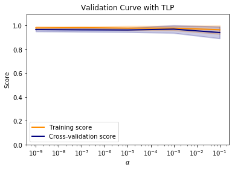

```python
plot_validation_curve(train_scores, test_scores, "$\\alpha$")
```

When varying $\alpha$ the score is about constant.

```python
# validate l2_C
clf = MyTLP(f_layer='relu', f_cost='cross', eta=10**-2.75,
            decrease_const=1e-7, epochs=150, alpha=1e-5)

param_range = np.logspace(-9, -1, 5)
train_scores, test_scores = validation_curve(clf, X, y, 'l2_C',
                                             param_range=param_range,
                                             cv=cv,
                                             scoring=my_scorer,
                                             n_jobs=4)
```

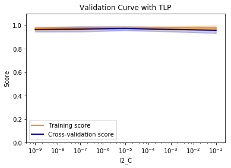

```python
plot_validation_curve(train_scores, test_scores, 'l2_C')
```

The score is also about constant when varying the L2_C parameter.

```
(0.95551724137931038, 1.0)
```

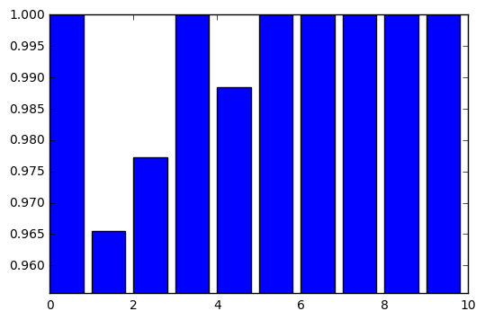

```python
# select model
clf = MyTLP(f_layer='relu', f_cost='cross', alpha=0, decrease_const=1e-07,
            eta=10**-2.75, epochs=500, l2_C=0.01)
#select cross validation
cv = StratifiedShuffleSplit(n_splits=10, test_size=0.05)

#_score = score_wrapper(recall_score)
#my_scorer = make_scorer(_score, average='micro')
_score = score_wrapper(weighted_recall_score)
my_scorer = make_scorer(_score, weight_matrix=weights)

# run model training and cross validation
per_fold_eval_criteria = cross_val_score(estimator=clf,
                                    X=X,
                                    y=y,
                                    cv=cv,
                                    scoring=my_scorer
                                   )
plt.bar(range(len(per_fold_eval_criteria)),per_fold_eval_criteria)
plt.ylim([min(per_fold_eval_criteria)-0.01,max(per_fold_eval_criteria)])
```

After tuning the parameters and using ReLU and cross entropy, we see a high increase in the score.

### Sklearn vs Us

After we tune our own implementation, we finish off this project by comparing ourselves to SKLearn's implementation.

```python
%load_ext memory_profiler

from sklearn import __version__ as sklearn_version
from sklearn.neural_network import MLPClassifier
from sklearn.metrics import accuracy_score
from sklearn.pipeline import make_pipeline
# but with this implementation we can also easily change Neurons
clf = MLPClassifier(hidden_layer_sizes=(50, ),
                    activation='relu', # type of non-linearity, every layer
                    solver='sgd',
                    alpha=1e-4, # L2 penalty
                    batch_size= 'auto', # min of 200, num_samples
                    learning_rate='constant', # adapt learning? only for sgd
                    learning_rate_init=0.1, # only SGD
                    power_t=0.0,    # only SGD with inverse scaling of learning rate
                    max_iter=75, # stopping criteria
                    shuffle=True,
                    random_state=1,
                    tol=0, # for stopping
                    verbose=False,
                    warm_start=False,
                    momentum=0.9, # only SGD
                    nesterovs_momentum=False, # only SGD
                    early_stopping=False,
                    validation_fraction=0.0, # only if early_stop is true
                    beta_1=0.9, # adam decay rate of moment
                    beta_2=0.999, # adam decay rate of moment
                    epsilon=1e-08) # adam numerical stabilizer
```

```python
%%time
%memit clf.fit(X,y)
```

```
peak memory: 135.76 MiB, increment: 0.00 MiB
CPU times: user 510 ms, sys: 10 ms, total: 520 ms
Wall time: 624 ms
```

```python
clf = MyTLP(f_layer='relu', f_cost='cross', alpha=0, eta=10**-2.75,
           epochs=150)
```

```python
%%time
%memit clf.fit(X,y)
```

```
peak memory: 137.37 MiB, increment: 1.62 MiB
CPU times: user 750 ms, sys: 13.3 ms, total: 763 ms
Wall time: 872 ms
```

```
(0.94454545454545458, 1.0)
```

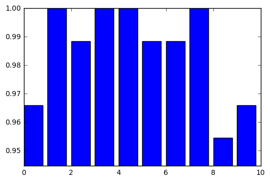

```python
clf = MLPClassifier(hidden_layer_sizes=(50, ),
                    activation='relu', # type of non-linearity, every layer
                    solver='sgd',
                    alpha=1e-4, # L2 penalty
                    batch_size= 'auto', # min of 200, num_samples
                    learning_rate='constant', # adapt learning? only for sgd
                    learning_rate_init=0.1, # only SGD
                    power_t=0.0,    # only SGD with inverse scaling of learning rate
                    max_iter=75, # stopping criteria
                    shuffle=True,
                    random_state=1,
                    tol=0, # for stopping
                    verbose=False,
                    warm_start=False,
                    momentum=0.9, # only SGD
                    nesterovs_momentum=False, # only SGD
                    early_stopping=False,
                    validation_fraction=0.0, # only if early_stop is true
                    beta_1=0.9, # adam decay rate of moment
                    beta_2=0.999, # adam decay rate of moment
                    epsilon=1e-08) # adam numerical stabilizer

#select cross validation
cv = StratifiedShuffleSplit(n_splits=10, test_size=0.05)

#_score = score_wrapper(recall_score)
#my_scorer = make_scorer(_score, average='micro')
_score = score_wrapper(weighted_recall_score)
my_scorer = make_scorer(_score, weight_matrix=weights)

# run model training and cross validation
per_fold_eval_criteria = cross_val_score(estimator=clf,
                                    X=X,
                                    y=y,
                                    cv=cv,
                                    scoring=my_scorer
                                   )
plt.bar(range(len(per_fold_eval_criteria)),per_fold_eval_criteria)
plt.ylim([min(per_fold_eval_criteria)-0.01,max(per_fold_eval_criteria)])
```

### Other Exceptional Work

#### Extra Hidden Layer

We added in an additional hidden layer to see how the performance would improve.

```python
# just start with the vectorized version and minibatch
class LeagueIsLife():
    def __init__(self, n_hidden=30,
                 l2_C=0.0, epochs=500, eta=0.001, random_state=None, alpha=0.0, decrease_const=0.0,
                 shuffle=True, minibatches=1, f_cost='quadratic', f_layer="sigmoid", tanh_a=0.0):

        #original initializer
        np.random.seed(random_state)
        self.n_hidden = n_hidden
        self.l2_C = l2_C
        self.epochs = epochs
        self.eta = eta
        # need to add to the original initializer
        self.alpha = alpha
        self.decrease_const = decrease_const
        self.shuffle = shuffle
        self.minibatches = minibatches
        self.f_cost = f_cost
        self.f_layer = f_layer
        self.tanh_a = tanh_a

    def _initialize_weights(self):
        """Initialize weights with small random numbers."""
        if self.f_layer == 'relu':
            init_bound = np.sqrt(6. / (self.n_hidden + self.n_features_ + 1))
            W1 = np.random.uniform(-init_bound, init_bound,(self.n_hidden, self.n_features_ + 1))

            init_bound = np.sqrt(6. / (self.n_hidden + self.n_hidden + 1))
            W2 = np.random.uniform(-init_bound, init_bound,(self.n_hidden, self.n_hidden + 1))

            init_bound = np.sqrt(2. / (self.n_output_ + self.n_hidden + 1))
            W3 = np.random.uniform(-init_bound, init_bound,(self.n_output_, self.n_hidden + 1))

        elif self.f_layer =='tanh':
            W1_num_elems = (self.n_features_ + 1)*self.n_hidden
            W1 = np.random.uniform(-6. / np.sqrt(W1_num_elems), 6. / np.sqrt(W1_num_elems), size=W1_num_elems)
            W1 = W1.reshape(self.n_hidden, self.n_features_ + 1) # reshape to be W

            W2_num_elems = (self.n_features_ + 1)*self.n_hidden
            W2 = np.random.uniform(-6. / np.sqrt(W2_num_elems), 6. / np.sqrt(W2_num_elems), size=W2_num_elems)
            W2 = W2.reshape(self.n_hidden, self.n_features_ + 1) # reshape to be W

            W3_num_elems = (self.n_hidden + 1)*self.n_output_
            W3 = np.random.uniform(-6. / np.sqrt(W3_num_elems), 6. / np.sqrt(W3_num_elems), size=W3_num_elems)
            W3 = W3.reshape(self.n_output_, self.n_hidden + 1)

        else:
            W1_num_elems = (self.n_features_ + 1)*self.n_hidden
            W1 = np.random.uniform(-1.0, 1.0,size=W1_num_elems)
            W1 = W1.reshape(self.n_hidden, self.n_features_ + 1) # reshape to be W

            W2_num_elems = (self.n_hidden + 1)*self.n_hidden
            W2 = np.random.uniform(-1.0, 1.0,size=W2_num_elems)
            W2 = W2.reshape(self.n_hidden, self.n_hidden + 1) # reshape to be W

            W3_num_elems = (self.n_hidden + 1)*self.n_output_
            W3 = np.random.uniform(-1.0, 1.0, size=W3_num_elems)
            W3 = W3.reshape(self.n_output_, self.n_hidden + 1)

        return W1, W2, W3

    @staticmethod
    def _sigmoid(z):
        """Use scipy.special.expit to avoid overflow"""
        # 1.0 / (1.0 + np.exp(-z))
        return expit(z)

    @staticmethod
    def _relu(Z):
        return np.maximum(0,Z.copy())

    #@staticmethod
    def _tanh(self, Z):
        return np.tanh(Z) + (self.tanh_a * Z)

    def _feedforward(self, X, W1, W2, W3):
        """Compute feedforward step
        """
        A1 = self._add_bias_unit(X, how='column')
        Z1 = W1 @ A1.T

        A2 = self._add_bias_unit(Z1, how='row')
        Z2 = W2 @ A2

        if self.f_layer == 'relu':
            A3 = self._relu(Z2)
        elif self.f_layer == 'tanh':
            A3 = self._tanh(Z2)
        else:
            A3 = self._sigmoid(Z2)

        A3 = self._add_bias_unit(A3,how='row')

        Z3 = W3 @ A3
        A4 = self._sigmoid(Z3)
        return A1, Z1, A2, Z2, A3, Z3, A4

    def fit(self, X, y, print_progress=False):
        """ Learn weights from training data. With mini-batch"""
        X_data, y_data = X.copy(), y.copy()
        Y_enc = self._encode_labels(y)

        # init weights and setup matrices
        self.n_features_ = X_data.shape[1]
        self.n_output_ = Y_enc.shape[0]
        self.W1, self.W2, self.W3 = self._initialize_weights()

        delta_W1_prev = np.zeros(self.W1.shape)
        delta_W2_prev = np.zeros(self.W2.shape)
        delta_W3_prev = np.zeros(self.W3.shape)

        self.cost_ = []
        self.score_ = []
        for i in range(self.epochs):

            # adaptive learning rate
            self.eta /= (1 + self.decrease_const*i)

            if print_progress>0 and (i+1)%print_progress==0:
                sys.stderr.write('\rEpoch: %d/%d' % (i+1, self.epochs))
                sys.stderr.flush()

            if self.shuffle:
                idx_shuffle = np.random.permutation(y_data.shape[0])
                X_data, Y_enc, y_data = X_data[idx_shuffle], Y_enc[:, idx_shuffle], y_data[idx_shuffle]

            mini = np.array_split(range(y_data.shape[0]), self.minibatches)
            mini_cost = []
            for idx in mini:

                # feedforward
                A1, Z1, A2, Z2, A3, Z3, A4 = self._feedforward(X_data[idx],
                                                       self.W1,
                                                       self.W2,
                                                        self.W3)

                cost = self._cost(A4,Y_enc[:,idx],self.W1,self.W2,self.W3)
                mini_cost.append(cost) # this appends cost of mini-batch only

                # compute gradient via backpropagation
                grad1, grad2, grad3 = self._get_gradient(A1=A1, A2=A2, A3=A3, Z1=Z1, Z2=Z2,
                                                  Z3=Z3,A4=A4,
                                                  Y_enc=Y_enc[:, idx],
                                                  W1=self.W1,W2=self.W2,W3=self.W3)

                delta_W1, delta_W2, delta_W3 = self.eta * grad1, self.eta * grad2, self.eta * grad3

                self.W1 -= (delta_W1 + (self.alpha * delta_W1_prev))
                self.W2 -= (delta_W2 + (self.alpha * delta_W2_prev))
                self.W3 -= (delta_W3 + (self.alpha * delta_W3_prev))

                delta_W1_prev, delta_W2_prev, delta_W3_prev = delta_W1, delta_W2, delta_W3

            self.cost_.append(mini_cost)
            self.score_.append(accuracy_score(y_data,self.predict(X_data)))

    def get_params(self, deep=True):
        return {"alpha": self.alpha, "f_cost": self.f_cost, "f_layer": self.f_layer, "l2_C": self.l2_C,
               "eta": self.eta, "decrease_const": self.decrease_const, "epochs": self.epochs}

    def _cost(self,A4,Y_enc,W1,W2,W3):
        # Cross entropy choice
        if self.f_cost == 'cross':
            '''Get the objective function value'''
            cost = np.mean((Y_enc-A4)**2)
            L2_term = self._L2_reg(self.l2_C, W1, W2, W3)
            return cost + L2_term
        # Quadradic (default) choice
        else:
            '''Get the objective function value'''
            cost = -np.mean(np.nan_to_num((Y_enc*np.log(A3)+(1-Y_enc)*np.log(1-A3))))
            L2_term = self._L2_reg(self.l2_C, W1, W2)
            return cost + L2_term

    def _get_gradient(self, A1, A2, A3,A4, Z1, Z2,Z3, Y_enc, W1, W2,W3):

        # Cross entrophy choice
        if self.f_cost == 'cross':
            sigma4 = (A4-Y_enc)
        else:
            sigma4 = -2*(Y_enc-A4)*A4*(1-A4)

        # Relu choice
        if self.f_layer == 'relu':
            sigma3 = (W3.T @ sigma4)
            Z2_with_bias = self._add_bias_unit(Z2,how='row')
            sigma3[Z2_with_bias<=0] = 0
            sigma2 = (W2.T @ sigma3[1:,:])
            Z1_with_bias = self._add_bias_unit(Z1,how='row')
            sigma2[Z1_with_bias<=0] = 0
        else:
            sigma3 = (W3.T @ sigma4)*A3*(1-A3)
            sigma2 = (W2.T @ sigma3)*A2*(1-A2)

        grad1 = sigma2[1:,:] @ A1
        grad2 = sigma3[1:,:] @ A2.T
        grad3 = sigma4 @ A3.T

        # regularize weights that are not bias terms
        grad1[:, 1:] += W1[:, 1:] * self.l2_C
        grad2[:, 1:] += W2[:, 1:] * self.l2_C
        grad3[:, 1:] += W3[:, 1:] * self.l2_C
        return grad1, grad2, grad3

    @staticmethod
    def _encode_labels(y):
        """Encode labels into one-hot representation"""
        onehot = pd.get_dummies(y).values.T
        return onehot

    @staticmethod
    def _add_bias_unit(X, how='column'):
        """Add bias unit (column or row of 1s) to array at index 0"""
        if how == 'column':
            ones = np.ones((X.shape[0], 1))
            X_new = np.hstack((ones, X))
        elif how == 'row':
            ones = np.ones((1, X.shape[1]))
            X_new = np.vstack((ones, X))
        return X_new

    @staticmethod
    def _L2_reg(lambda_, W1, W2, W3):
        """Compute L2-regularization cost"""
        # only compute for non-bias terms
        return (lambda_/2.0) * np.sqrt(np.mean(W1[:, 1:] ** 2) + np.mean(W2[:, 1:] ** 2) + np.mean(W3[:,1:] ** 2))

    def predict(self, X):
        """Predict class labels"""
        _, _, _, _, _, _, A4 = self._feedforward(X, self.W1, self.W2, self.W3)
        y_pred = np.argmax(A4, axis=0)
        return y_pred

    def set_params(self, **parameters):
        for parameter, value in parameters.items():
            self.__setattr__(parameter, value)
        return self
```

```python
from sklearn.model_selection import GridSearchCV
from sklearn.preprocessing import StandardScaler
from sklearn.pipeline import make_pipeline
from sklearn import __version__ as sklearn_version
from sklearn.neural_network import MLPClassifier
from sklearn.metrics import accuracy_score
from sklearn.preprocessing import StandardScaler
from sklearn.pipeline import make_pipeline

from sklearn.model_selection import cross_val_score
from sklearn.model_selection import KFold, ShuffleSplit
from sklearn.model_selection import StratifiedKFold, StratifiedShuffleSplit

from sklearn.metrics import make_scorer, accuracy_score
from sklearn.metrics import precision_score, recall_score, f1_score
from sklearn.metrics import accuracy_score

from sklearn.metrics import confusion_matrix

# High cost for false negatives on "unacceptable" class
weights = np.array([
    [0, 2, 2, 2],
    [1, 0, 1, 1],
    [1, 1, 0, 1],
    [1, 1, 1, 0]
])
cv = StratifiedShuffleSplit(n_splits=10, test_size=0.05)

def weighted_recall_score(y_true, y_pred, weight_matrix):
    conf_matrix = confusion_matrix(y_true, y_pred)

    tp = np.sum(np.diagonal(conf_matrix))
    fn = np.sum(weight_matrix * conf_matrix)

    return tp / (tp + fn)

# alpha, f_layer, f_cost, epochs, eta, C, decrease_const
parameters = {'f_cost':('cross',), 'f_layer':('relu',), 'eta': [0.001, 0.01, 0.1],
              'epochs': [75], 'l2_C':[1e-2, 1e-1, 0.0],
              'decrease_const':[1e-9, 1e-5, 0.0], 'alpha':[0.0, 0.01, 0.001]}

tlp = LeagueIsLife()

my_scorer = make_scorer(weighted_recall_score, weight_matrix=weights)
clf = GridSearchCV(tlp, parameters, scoring=my_scorer, cv=cv)
clf.fit(X, y)
results = pd.DataFrame(clf.cv_results_)
results.sort(columns=['mean_test_score'], ascending=False)
```

|  | mean_fit_time | mean_score_time | mean_test_score | mean_train_score | param_alpha | param_decrease_const | param_epochs | param_eta | param_f_cost | param_f_layer | ... | split7_test_score | split7_train_score | split8_test_score | split8_train_score | split9_test_score | split9_train_score | std_fit_time | std_score_time | std_test_score | std_train_score |
| --- | --- | --- | --- | --- | --- | --- | --- | --- | --- | --- | --- | --- | --- | --- | --- | --- | --- | --- | --- | --- | --- |
| 72 | 0.629123 | 0.000645 | 0.876715 | 0.868906 | 0.001 | 0 | 75 | 0.001 | cross | relu | ... | 0.897727 | 0.859753 | 0.876404 | 0.890766 | 0.752577 | 0.755482 | 0.007543 | 0.000015 | 0.054611 | 0.059048 |
| 64 | 0.619358 | 0.000638 | 0.842762 | 0.850049 | 0.001 | 1e-05 | 75 | 0.001 | cross | relu | ... | 0.873563 | 0.871359 | 0.855556 | 0.872619 | 0.653465 | 0.705218 | 0.020669 | 0.000025 | 0.091758 | 0.079196 |
| 19 | 0.619278 | 0.000637 | 0.833866 | 0.843397 | 0 | 0 | 75 | 0.001 | cross | relu | ... | 0.784091 | 0.840000 | 0.824176 | 0.839766 | 0.910112 | 0.901466 | 0.015860 | 0.000029 | 0.072002 | 0.079174 |
| 55 | 0.608671 | 0.000619 | 0.822431 | 0.836273 | 0.001 | 1e-09 | 75 | 0.001 | cross | relu | ... | 0.897727 | 0.924242 | 0.797753 | 0.864242 | 0.876404 | 0.894421 | 0.017816 | 0.000015 | 0.085329 | 0.092451 |
| 2 | 0.615743 | 0.000631 | 0.821981 | 0.815291 | 0 | 1e-09 | 75 | 0.001 | cross | relu | ... | 0.815217 | 0.731614 | 0.680000 | 0.698608 | 0.852273 | 0.849760 | 0.017316 | 0.000020 | 0.075833 | 0.081624 |
| 10 | 0.622571 | 0.000634 | 0.819897 | 0.825524 | 0 | 1e-05 | 75 | 0.001 | cross | relu | ... | 0.932584 | 0.883991 | 0.863636 | 0.881325 | 0.839080 | 0.837068 | 0.048221 | 0.000041 | 0.083295 | 0.081113 |
| 18 | 0.616611 | 0.000635 | 0.817197 | 0.813191 | 0 | 0 | 75 | 0.001 | cross | relu | ... | 0.911111 | 0.799100 | 0.744444 | 0.788942 | 0.701149 | 0.700183 | 0.017971 | 0.000024 | 0.088925 | 0.081311 |
| 0 | 0.606185 | 0.000629 | 0.814401 | 0.824794 | 0 | 1e-09 | 75 | 0.001 | cross | relu | ... | 0.840909 | 0.891041 | 0.833333 | 0.861144 | 0.852273 | 0.866506 | 0.017373 | 0.000035 | 0.085984 | 0.086049 |
| 54 | 0.608032 | 0.000626 | 0.806569 | 0.812866 | 0.001 | 1e-09 | 75 | 0.001 | cross | relu | ... | 0.701149 | 0.700183 | 0.701149 | 0.700183 | 0.815217 | 0.810098 | 0.012490 | 0.000019 | 0.066750 | 0.069164 |
| 9 | 0.613061 | 0.000619 | 0.800578 | 0.788684 | 0 | 1e-05 | 75 | 0.001 | cross | relu | ... | 0.747368 | 0.631329 | 0.704082 | 0.701726 | 0.860215 | 0.889801 | 0.018761 | 0.000008 | 0.105327 | 0.142330 |
| 65 | 0.612965 | 0.000650 | 0.798092 | 0.768375 | 0.001 | 1e-05 | 75 | 0.001 | cross | relu | ... | 0.808511 | 0.692186 | 0.898876 | 0.948454 | 0.701149 | 0.700183 | 0.023898 | 0.000059 | 0.087012 | 0.100098 |
| 63 | 0.609180 | 0.000626 | 0.794747 | 0.794768 | 0.001 | 1e-05 | 75 | 0.001 | cross | relu | ... | 0.761364 | 0.801563 | 0.833333 | 0.858929 | 0.701149 | 0.700183 | 0.012169 | 0.000017 | 0.079167 | 0.086345 |
| 36 | 0.606911 | 0.000628 | 0.793177 | 0.785429 | 0.01 | 1e-05 | 75 | 0.001 | cross | relu | ... | 0.795699 | 0.681770 | 0.701149 | 0.700183 | 0.840909 | 0.836943 | 0.014836 | 0.000022 | 0.066214 | 0.084623 |
| 38 | 0.599854 | 0.000621 | 0.786577 | 0.785315 | 0.01 | 1e-05 | 75 | 0.001 | cross | relu | ... | 0.701149 | 0.700183 | 0.708333 | 0.735722 | 0.701149 | 0.700183 | 0.017281 | 0.000018 | 0.077998 | 0.075025 |
| 1 | 0.607601 | 0.000625 | 0.778156 | 0.767178 | 0 | 1e-09 | 75 | 0.001 | cross | relu | ... | 0.701149 | 0.700183 | 0.701031 | 0.684670 | 0.862069 | 0.866828 | 0.019337 | 0.000020 | 0.082448 | 0.073504 |
| 74 | 0.599510 | 0.000625 | 0.777548 | 0.765411 | 0.001 | 0 | 75 | 0.001 | cross | relu | ... | 0.888889 | 0.809955 | 0.863636 | 0.904126 | 0.701149 | 0.700183 | 0.017363 | 0.000023 | 0.081631 | 0.077815 |
| 46 | 0.594583 | 0.000616 | 0.776587 | 0.784425 | 0.01 | 0 | 75 | 0.001 | cross | relu | ... | 0.829545 | 0.859121 | 0.701149 | 0.700183 | 0.681818 | 0.700183 | 0.013689 | 0.000012 | 0.081954 | 0.083693 |
| 29 | 0.608560 | 0.000620 | 0.775996 | 0.795988 | 0.01 | 1e-09 | 75 | 0.001 | cross | relu | ... | 0.820225 | 0.862418 | 0.653465 | 0.683565 | 0.721649 | 0.736379 | 0.014370 | 0.000014 | 0.084460 | 0.088236 |
| 56 | 0.602832 | 0.000630 | 0.771932 | 0.769091 | 0.001 | 1e-09 | 75 | 0.001 | cross | relu | ... | 0.852273 | 0.919951 | 0.701149 | 0.700183 | 0.873563 | 0.876214 | 0.014071 | 0.000022 | 0.088967 | 0.089015 |
| 27 | 0.609812 | 0.000644 | 0.768017 | 0.767490 | 0.01 | 1e-09 | 75 | 0.001 | cross | relu | ... | 0.336000 | 0.307501 | 0.795699 | 0.809060 | 0.865169 | 0.843183 | 0.012936 | 0.000033 | 0.159287 | 0.166040 |
| 47 | 0.595936 | 0.000626 | 0.766978 | 0.769727 | 0.01 | 0 | 75 | 0.001 | cross | relu | ... | 0.701149 | 0.700183 | 0.701149 | 0.700183 | 0.954545 | 0.923442 | 0.013356 | 0.000016 | 0.089232 | 0.087772 |
| 11 | 0.606119 | 0.000625 | 0.762726 | 0.764958 | 0 | 1e-05 | 75 | 0.001 | cross | relu | ... | 0.701149 | 0.700183 | 0.840909 | 0.855763 | 0.701149 | 0.700183 | 0.017052 | 0.000014 | 0.225618 | 0.217936 |
| 28 | 0.597679 | 0.000627 | 0.751268 | 0.764902 | 0.01 | 1e-09 | 75 | 0.001 | cross | relu | ... | 0.943182 | 0.957022 | 0.653465 | 0.680874 | 0.852273 | 0.857917 | 0.019408 | 0.000016 | 0.090512 | 0.092517 |
| 20 | 0.596816 | 0.000622 | 0.750631 | 0.751284 | 0 | 0 | 75 | 0.001 | cross | relu | ... | 0.701149 | 0.700183 | 0.711340 | 0.741351 | 0.863636 | 0.855856 | 0.018066 | 0.000023 | 0.073354 | 0.067788 |
| 45 | 0.600626 | 0.000619 | 0.750275 | 0.771869 | 0.01 | 0 | 75 | 0.001 | cross | relu | ... | 0.909091 | 0.941319 | 0.701149 | 0.700183 | 0.721649 | 0.731614 | 0.019349 | 0.000015 | 0.076474 | 0.083140 |
| 73 | 0.610652 | 0.000629 | 0.748640 | 0.764314 | 0.001 | 0 | 75 | 0.001 | cross | relu | ... | 0.806818 | 0.860959 | 0.824176 | 0.848467 | 0.827586 | 0.817629 | 0.013624 | 0.000016 | 0.147520 | 0.149443 |
| 37 | 0.604213 | 0.000629 | 0.740472 | 0.746546 | 0.01 | 1e-05 | 75 | 0.001 | cross | relu | ... | 0.701149 | 0.700183 | 0.721649 | 0.762570 | 0.919540 | 0.917017 | 0.017927 | 0.000019 | 0.133363 | 0.130629 |
| 49 | 0.569220 | 0.000609 | 0.701149 | 0.700183 | 0.01 | 0 | 75 | 0.01 | cross | relu | ... | 0.701149 | 0.700183 | 0.701149 | 0.700183 | 0.701149 | 0.700183 | 0.009361 | 0.000012 | 0.000000 | 0.000000 |
| 59 | 0.565496 | 0.000611 | 0.701149 | 0.700183 | 0.001 | 1e-09 | 75 | 0.01 | cross | relu | ... | 0.701149 | 0.700183 | 0.701149 | 0.700183 | 0.701149 | 0.700183 | 0.005723 | 0.000016 | 0.000000 | 0.000000 |
| 66 | 0.581786 | 0.000644 | 0.701149 | 0.700183 | 0.001 | 1e-05 | 75 | 0.01 | cross | relu | ... | 0.701149 | 0.700183 | 0.701149 | 0.700183 | 0.701149 | 0.700183 | 0.009849 | 0.000033 | 0.000000 | 0.000000 |
| ... | ... | ... | ... | ... | ... | ... | ... | ... | ... | ... | ... | ... | ... | ... | ... | ... | ... | ... | ... | ... | ... |
| 7 | 0.663501 | 0.000670 | 0.586595 | 0.586311 | 0 | 1e-09 | 75 | 0.1 | cross | relu | ... | 0.701149 | 0.700183 | 0.701149 | 0.700183 | 0.701149 | 0.700183 | 0.078141 | 0.000111 | 0.229108 | 0.227743 |
| 76 | 0.567937 | 0.000613 | 0.586595 | 0.586311 | 0.001 | 0 | 75 | 0.01 | cross | relu | ... | 0.701149 | 0.700183 | 0.701149 | 0.700183 | 0.701149 | 0.700183 | 0.005942 | 0.000019 | 0.229108 | 0.227743 |
| 41 | 0.564284 | 0.000605 | 0.586595 | 0.586311 | 0.01 | 1e-05 | 75 | 0.01 | cross | relu | ... | 0.701149 | 0.700183 | 0.701149 | 0.700183 | 0.701149 | 0.700183 | 0.005120 | 0.000004 | 0.229108 | 0.227743 |
| 52 | 0.566489 | 0.000610 | 0.529318 | 0.529375 | 0.01 | 0 | 75 | 0.1 | cross | relu | ... | 0.701149 | 0.700183 | 0.701149 | 0.700183 | 0.701149 | 0.700183 | 0.006053 | 0.000016 | 0.262477 | 0.260913 |
| 6 | 0.688395 | 0.000742 | 0.529318 | 0.529375 | 0 | 1e-09 | 75 | 0.1 | cross | relu | ... | 0.701149 | 0.700183 | 0.701149 | 0.700183 | 0.128378 | 0.130824 | 0.109310 | 0.000180 | 0.262477 | 0.260913 |
| 25 | 0.567531 | 0.000606 | 0.519183 | 0.518623 | 0 | 0 | 75 | 0.1 | cross | relu | ... | 0.027027 | 0.023297 | 0.701149 | 0.700183 | 0.701149 | 0.700183 | 0.008608 | 0.000010 | 0.279187 | 0.278724 |
| 31 | 0.576166 | 0.000626 | 0.472041 | 0.472439 | 0.01 | 1e-09 | 75 | 0.01 | cross | relu | ... | 0.701149 | 0.700183 | 0.701149 | 0.700183 | 0.128378 | 0.130824 | 0.007635 | 0.000014 | 0.280599 | 0.278928 |
| 78 | 0.565738 | 0.000615 | 0.472041 | 0.472439 | 0.001 | 0 | 75 | 0.1 | cross | relu | ... | 0.701149 | 0.700183 | 0.128378 | 0.130824 | 0.128378 | 0.130824 | 0.006756 | 0.000016 | 0.280599 | 0.278928 |
| 62 | 0.568665 | 0.000612 | 0.461906 | 0.461687 | 0.001 | 1e-09 | 75 | 0.1 | cross | relu | ... | 0.027027 | 0.023297 | 0.701149 | 0.700183 | 0.128378 | 0.130824 | 0.008365 | 0.000015 | 0.294324 | 0.293577 |
| 53 | 0.566213 | 0.000623 | 0.461230 | 0.461579 | 0.01 | 0 | 75 | 0.1 | cross | relu | ... | 0.701149 | 0.700183 | 0.020270 | 0.022222 | 0.128378 | 0.130824 | 0.005600 | 0.000023 | 0.295328 | 0.293738 |
| 17 | 0.566294 | 0.000606 | 0.414764 | 0.415504 | 0 | 1e-05 | 75 | 0.1 | cross | relu | ... | 0.701149 | 0.700183 | 0.701149 | 0.700183 | 0.701149 | 0.700183 | 0.005195 | 0.000013 | 0.286386 | 0.284679 |
| 44 | 0.569010 | 0.000610 | 0.414764 | 0.415504 | 0.01 | 1e-05 | 75 | 0.1 | cross | relu | ... | 0.128378 | 0.130824 | 0.701149 | 0.700183 | 0.128378 | 0.130824 | 0.007362 | 0.000017 | 0.286386 | 0.284679 |
| 70 | 0.571902 | 0.000632 | 0.414764 | 0.415504 | 0.001 | 1e-05 | 75 | 0.1 | cross | relu | ... | 0.128378 | 0.130824 | 0.701149 | 0.700183 | 0.128378 | 0.130824 | 0.009899 | 0.000032 | 0.286386 | 0.284679 |
| 69 | 0.580874 | 0.000648 | 0.414764 | 0.415504 | 0.001 | 1e-05 | 75 | 0.1 | cross | relu | ... | 0.128378 | 0.130824 | 0.128378 | 0.130824 | 0.701149 | 0.700183 | 0.003995 | 0.000017 | 0.286386 | 0.284679 |
| 24 | 0.566915 | 0.000612 | 0.414764 | 0.415504 | 0 | 0 | 75 | 0.1 | cross | relu | ... | 0.128378 | 0.130824 | 0.701149 | 0.700183 | 0.701149 | 0.700183 | 0.005154 | 0.000011 | 0.286386 | 0.284679 |
| 42 | 0.565693 | 0.000613 | 0.394494 | 0.393998 | 0.01 | 1e-05 | 75 | 0.1 | cross | relu | ... | 0.701149 | 0.700183 | 0.027027 | 0.023297 | 0.128378 | 0.130824 | 0.006518 | 0.000014 | 0.308659 | 0.308442 |
| 60 | 0.565991 | 0.000608 | 0.394494 | 0.393998 | 0.001 | 1e-09 | 75 | 0.1 | cross | relu | ... | 0.027027 | 0.023297 | 0.701149 | 0.700183 | 0.128378 | 0.130824 | 0.005878 | 0.000011 | 0.308659 | 0.308442 |
| 80 | 0.568018 | 0.000624 | 0.357487 | 0.358568 | 0.001 | 0 | 75 | 0.1 | cross | relu | ... | 0.128378 | 0.130824 | 0.128378 | 0.130824 | 0.701149 | 0.700183 | 0.009598 | 0.000027 | 0.280599 | 0.278928 |
| 16 | 0.569425 | 0.000619 | 0.357487 | 0.358568 | 0 | 1e-05 | 75 | 0.1 | cross | relu | ... | 0.128378 | 0.130824 | 0.128378 | 0.130824 | 0.128378 | 0.130824 | 0.008991 | 0.000024 | 0.280599 | 0.278928 |
| 43 | 0.567822 | 0.000609 | 0.357487 | 0.358568 | 0.01 | 1e-05 | 75 | 0.1 | cross | relu | ... | 0.128378 | 0.130824 | 0.128378 | 0.130824 | 0.701149 | 0.700183 | 0.007072 | 0.000012 | 0.280599 | 0.278928 |
| 79 | 0.567637 | 0.000615 | 0.347352 | 0.347815 | 0.001 | 0 | 75 | 0.1 | cross | relu | ... | 0.128378 | 0.130824 | 0.701149 | 0.700183 | 0.128378 | 0.130824 | 0.010598 | 0.000015 | 0.290353 | 0.289377 |
| 34 | 0.568338 | 0.000619 | 0.347352 | 0.347815 | 0.01 | 1e-09 | 75 | 0.1 | cross | relu | ... | 0.128378 | 0.130824 | 0.128378 | 0.130824 | 0.701149 | 0.700183 | 0.007560 | 0.000017 | 0.290353 | 0.289377 |
| 61 | 0.563745 | 0.000615 | 0.346676 | 0.347708 | 0.001 | 1e-09 | 75 | 0.1 | cross | relu | ... | 0.128378 | 0.130824 | 0.128378 | 0.130824 | 0.701149 | 0.700183 | 0.005289 | 0.000022 | 0.291104 | 0.289497 |
| 8 | 0.632919 | 0.000699 | 0.300210 | 0.301632 | 0 | 1e-09 | 75 | 0.1 | cross | relu | ... | 0.701149 | 0.700183 | 0.128378 | 0.130824 | 0.128378 | 0.130824 | 0.063642 | 0.000138 | 0.262477 | 0.260913 |
| 15 | 0.565395 | 0.000606 | 0.300210 | 0.301632 | 0 | 1e-05 | 75 | 0.1 | cross | relu | ... | 0.701149 | 0.700183 | 0.128378 | 0.130824 | 0.128378 | 0.130824 | 0.005797 | 0.000006 | 0.262477 | 0.260913 |
| 71 | 0.568215 | 0.000615 | 0.290075 | 0.290879 | 0.001 | 1e-05 | 75 | 0.1 | cross | relu | ... | 0.128378 | 0.130824 | 0.128378 | 0.130824 | 0.128378 | 0.130824 | 0.009364 | 0.000017 | 0.270743 | 0.269795 |
| 51 | 0.564534 | 0.000642 | 0.289399 | 0.290772 | 0.01 | 0 | 75 | 0.1 | cross | relu | ... | 0.128378 | 0.130824 | 0.701149 | 0.700183 | 0.701149 | 0.700183 | 0.004772 | 0.000075 | 0.271406 | 0.269902 |
| 33 | 0.572568 | 0.000632 | 0.289399 | 0.290772 | 0.01 | 1e-09 | 75 | 0.1 | cross | relu | ... | 0.128378 | 0.130824 | 0.020270 | 0.022222 | 0.701149 | 0.700183 | 0.007204 | 0.000026 | 0.271406 | 0.269902 |
| 35 | 0.576827 | 0.000624 | 0.289399 | 0.290772 | 0.01 | 1e-09 | 75 | 0.1 | cross | relu | ... | 0.128378 | 0.130824 | 0.701149 | 0.700183 | 0.128378 | 0.130824 | 0.011876 | 0.000016 | 0.271406 | 0.269902 |
| 26 | 0.568949 | 0.000616 | 0.289399 | 0.290772 | 0 | 0 | 75 | 0.1 | cross | relu | ... | 0.701149 | 0.700183 | 0.128378 | 0.130824 | 0.020270 | 0.022222 | 0.005549 | 0.000018 | 0.271406 | 0.269902 |

81 rows × 37 columns

#### Results

So it looks as though the extra layer gives little to no benefit in terms of performance. It is possible that with a different selection of layers and some more tweaks we could get the four layer network to perform at a much higher accuracy rate than the three layer network.

It is also possible that the lower accuracy results from an error in the gradient calculation of the new class. Typically, in small neural networks it is more beneficial to introduce additional nodes to the hidden layer than it is to add in an additional layer.

```
(0.96727272727272728, 1.0)
```

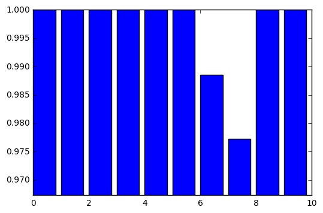

```python
clf = MyTLP(f_layer='relu', f_cost='cross', alpha=0, decrease_const=1e-07,
            eta=10**-2.75, epochs=500, l2_C=0.01,n_hidden=100)
#select cross validation
cv = StratifiedShuffleSplit(n_splits=10, test_size=0.05)

#_score = score_wrapper(recall_score)
#my_scorer = make_scorer(_score, average='micro')
_score = score_wrapper(weighted_recall_score)
my_scorer = make_scorer(_score, weight_matrix=weights)

# run model training and cross validation
per_fold_eval_criteria = cross_val_score(estimator=clf,
                                    X=X,
                                    y=y,
                                    cv=cv,
                                    scoring=my_scorer
                                   )
plt.bar(range(len(per_fold_eval_criteria)),per_fold_eval_criteria)
plt.ylim([min(per_fold_eval_criteria)-0.01,max(per_fold_eval_criteria)])
```

This model is achieving really incredible accuracy on the dataset.